# Carotid atherosclerotic plaque in adults with and without rheumatoid arthritis

Dataset 10: Cardiovascular risk and carotid artery thickness in rheumatoid arthritis

RSR feasibility analysis

2026-08-03

# Introduction

The source study recruited adults with rheumatoid arthritis (RA) and healthy controls without RA in the Netherlands, put every participant through the same physical examination and fasting laboratory panel, and scanned both carotid arteries by B-mode ultrasound (Hollan and colleagues, *PLOS ONE*, 2015). As well as measuring wall thickness the ultrasound recorded whether a discrete atherosclerotic **plaque** was present. Plaque is a later and clinically harder endpoint than wall thickening - it is focal, it is what ruptures, and its presence reclassifies cardiovascular risk in a way that a continuous thickness measurement does not - so it is worth asking separately whether RA and the conventional risk factors predict it.

**Aim.** Among these Dutch adults, we examined which of RA status, age, sex, systolic blood pressure, current smoking and total cholesterol are independently associated with the presence of carotid plaque, mutually adjusting for the others.

This is a *Purpose 3* analysis: several predictors are of interest and the question is which remain associated with the outcome after mutual adjustment.

# Methods

**Data source.** A cross-sectional case-control comparison conducted in the Netherlands and published in *PLOS ONE* in 2015. Cases were adults with established rheumatoid arthritis; controls were adults without RA recruited from the same setting. This extract contains 470 participants (307 with RA, 163 controls) and 25 variables. Ages run from 20 to 70 years.

**Variables.** The outcome is `carotid_plaque`, a binary indicator where the **event is an atherosclerotic plaque visible on carotid ultrasound**. There are 65 events among the 428 participants scanned (15.2%). Predictors are rheumatoid arthritis status (reference Control), age in years, sex (reference Female), systolic blood pressure in mmHg, current smoking (reference No) and total cholesterol in mmol/L. **RA status is the exposure of primary interest**; the other five are the conventional determinants of atherosclerosis.

**The predictor set is deliberately small, and here is the arithmetic.** The file contains 65 plaque events and 65 survive into the complete-case analytic sample. The conventional rule of **ten events per estimated parameter** therefore allows 6 parameters. All six predictors are continuous or binary, so each costs exactly one degree of freedom and the model estimates 6 parameters, giving **10.8 events per parameter**. That is the budget spent, with nothing to spare. The `meta.json` predictor list contains 16 variables; fitting all of them would cost 16-17 parameters and drop events per parameter to about 3.8, which is over-fitting regardless of what the p-values then say. The six were chosen a priori: age and sex because cases and controls were **not matched** on either and both are the dominant determinants of plaque; RA status because it is the exposure of interest; and blood pressure, smoking and total cholesterol because they are the three modifiable risk factors that any cardiovascular model would be expected to contain.

**Variables excluded from the candidate pool on structural grounds.** `ldl_cholesterol` is not independently measured in this file - it is the Friedewald calculation from total cholesterol, HDL and triglycerides (correlation 0.9987 with that formula), so it must never appear alongside all three. `waist_cm` duplicates `bmi` (r 0.81) and `diastolic_bp` duplicates `systolic_bp` (r 0.67); `apo_a` and `apo_b` duplicate HDL and total cholesterol. `weight_kg` and `height_cm` are excluded because `bmi` is exactly `weight_kg/(height_cm/100)^2`. `statins` and `antihypertensives` are omitted from *this* model for a different reason - they are confounded by indication and each would cost a scarce parameter to estimate something that cannot be read as a treatment effect (see Discussion). `prednisone` is omitted because it is almost perfectly aligned with RA status (1 of 39 users are controls).

**Statistical analysis.** `glm(family = binomial)`, justified because the outcome is binary. We fitted a univariable model for each predictor first, then a single multivariable model containing all six. Predictors were chosen in advance on subject-matter grounds, not by significance. Coefficients are exponentiated and reported as odds ratios with 95% confidence intervals; significance threshold 0.05. Model adequacy was assessed with `performance::check_model()`, `binned_residuals()` and `check_collinearity()`, focusing on calibration, collinearity, influential observations and events per parameter. Analysis used R version 4.6.0 (2026-04-24) with tidyverse, gtsummary and performance.

**Data integrity.** The catalogue notes that in the original Zenodo deposit `sex` was coded 0 = woman / 1 = man and the height column mixed metres and centimetres. Both are corrected here: `sex` ships as the strings female and male and `height_cm` runs from 145 to 206 cm with 0 values below 3. One defect remains: row `id = "control_row1"` is entirely blank apart from `id`, `has_ra` and `hypertension_or_hyperchol`.

**Missing data.** Complete-case analysis: 425 of 470 rows were analysed (45 dropped, 9.6%), leaving 65 events. Almost all the loss is the outcome itself: `carotid_plaque` is only 91.1% complete (42 missing). **That missingness is severely differential with respect to the exposure of interest**: 3 of 307 RA cases (1.0%) lack a plaque reading, against 39 of 163 controls (23.9%). Nearly a quarter of the control group is therefore absent from this analysis for reasons we cannot observe, and if plaque status is related to whether a control was scanned, the RA-versus-control comparison is biased by an unknown amount in an unknown direction. This is stated again in the Limitations because it is the most serious weakness of this outcome.

# Results

## Sample characteristics

**Table 1. Sample characteristics by carotid plaque status.**

| **Characteristic** | **N** | **No plaque** N = 360<sup>1</sup> | **Plaque** N = 65<sup>1</sup> |
| --- | --- | --- | --- |
| Age (years) | 425 | 52 (44, 60) | 62 (58, 67) |
| Sex | 425 |  |  |
| Female |  | 247 (69%) | 30 (46%) |
| Male |  | 113 (31%) | 35 (54%) |
| Rheumatoid arthritis | 425 |  |  |
| Control |  | 103 (29%) | 21 (32%) |
| RA |  | 257 (71%) | 44 (68%) |
| Systolic BP (mmHg) | 425 | 130 (120, 140) | 135 (124, 145) |
| Current smoker | 425 | 69 (19%) | 16 (25%) |
| Total cholesterol (mmol/L) | 425 | 5.35 (4.60, 6.00) | 5.60 (4.40, 6.50) |

<sup>1</sup> Median (Q1, Q3); n (%)

Participants with plaque are a decade older (median 62 versus 52 years), more often male (54% versus 31%) and have higher systolic pressure. RA status looks almost irrelevant: 14.6% of RA cases have plaque against 16.9% of controls.

## Exploratory figure

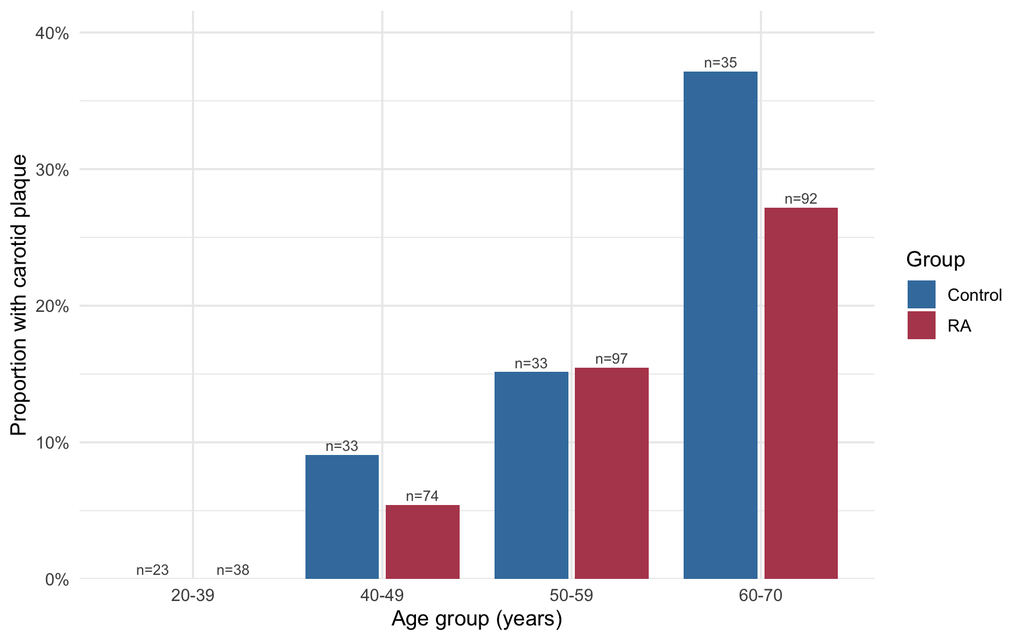

Figure 1. Proportion with carotid plaque by age group and rheumatoid arthritis status. Group sizes are printed above each bar.

## Univariable models

| **Characteristic** | **N** | **OR** | **95% CI** | **p-value** |
| --- | --- | --- | --- | --- |
| Age (years) | 425 | 1.12 | 1.08, 1.16 | <0.001 |
| Sex | 425 |  |  |  |
| Female |  | — | — |  |
| Male |  | 2.55 | 1.49, 4.38 | <0.001 |
| Rheumatoid arthritis | 425 |  |  |  |
| Control |  | — | — |  |
| RA |  | 0.84 | 0.48, 1.50 | 0.5 |
| Systolic BP (mmHg) | 425 | 1.02 | 1.01, 1.03 | 0.005 |
| Current smoker | 425 |  |  |  |
| No |  | — | — |  |
| Yes |  | 1.38 | 0.72, 2.52 | 0.3 |
| Total cholesterol (mmol/L) | 425 | 1.18 | 0.92, 1.51 | 0.2 |

Abbreviations: CI = Confidence Interval, OR = Odds Ratio

Age dominates. Each additional year multiplies the odds of carotid plaque by OR 1.12 (95% CI 1.08 to 1.16) (p <0.001), which compounds to roughly 3.0-fold per decade. Men have OR 2.55 (95% CI 1.49 to 4.38) the odds of women (p <0.001). Each additional mmHg of systolic pressure multiplies the odds by OR 1.02 (95% CI 1.01 to 1.03) (p = 0.005), about 1.22-fold per 10 mmHg. The remaining three show no crude association: total cholesterol (OR 1.18 (95% CI 0.92 to 1.51) per mmol/L, p = 0.197), current smoking (OR 1.38 (95% CI 0.72 to 2.52), p = 0.314) and - the exposure of interest - RA status (OR 0.84 (95% CI 0.48 to 1.50), p = 0.547), whose confidence interval spans both a halving and a fifty-per-cent increase in the odds.

## Multivariable model

| **Characteristic** | **OR** | **95% CI** | **p-value** |
| --- | --- | --- | --- |
| Age (years) | 1.12 | 1.08, 1.17 | <0.001 |
| Sex |  |  |  |
| Female | — | — |  |
| Male | 2.39 | 1.32, 4.36 | 0.004 |
| Rheumatoid arthritis |  |  |  |
| Control | — | — |  |
| RA | 0.70 | 0.37, 1.35 | 0.3 |
| Systolic BP (mmHg) | 1.00 | 0.99, 1.02 | 0.6 |
| Current smoker |  |  |  |
| No | — | — |  |
| Yes | 2.17 | 1.07, 4.32 | 0.029 |
| Total cholesterol (mmol/L) | 1.00 | 0.75, 1.32 | >0.9 |

Abbreviations: CI = Confidence Interval, OR = Odds Ratio

**Model fit: multivariable logistic model for carotid plaque**

| Statistic | Value |
| --- | --- |
| Complete-case N | 425 |
| Events (plaque = 1) | 65 |
| Parameters (excl. intercept) | 6 |
| Events per parameter | 10.8 |
| AIC (null model) | 365.6 |
| AIC (full model) | 314.7 |
| Tjur's R-squared | 0.141 |

The model has 65 events for 6 estimated parameters, i.e. **10.8 events per parameter**, which clears the conventional minimum of ten but only because the predictor set was capped at six in advance. AIC falls from 365.6 for the intercept-only model to 314.7, a drop of 50.9, so the predictors collectively carry real information; Tjur’s R-squared is 0.141, which is modest - the model separates plaque from no-plaque only partially.

Three predictors are independently associated with plaque. Among participants of the same sex, RA status, blood pressure, smoking status and cholesterol, each additional year of age multiplies the odds of plaque by OR 1.12 (95% CI 1.08 to 1.17) (p <0.001), about 3.1-fold per decade. Among participants alike on everything else, men have OR 2.39 (95% CI 1.32 to 4.36) the odds of women (p = 0.004), and current smokers OR 2.17 (95% CI 1.07 to 4.32) the odds of non-smokers (p = 0.029). The exposure of interest remains null: among participants of the same age, sex and risk-factor profile, RA is associated with OR 0.70 (95% CI 0.37 to 1.35) (p = 0.283) - a point estimate suggesting somewhat *lower* odds, but with a confidence interval that comfortably includes no association and a 35% increase. Systolic blood pressure (OR 1.00 (95% CI 0.99 to 1.02), p = 0.578) and total cholesterol (OR 1.00 (95% CI 0.75 to 1.32), p = 0.987) are both null after adjustment. These are associations among the participants observed, not effects of intervening.

## Unadjusted versus adjusted

**Table 2. Unadjusted and adjusted odds ratios for carotid plaque.**

| **Characteristic** | **Unadjusted** **N** | **Unadjusted** **OR** | **Unadjusted** **95% CI** | **Unadjusted** **p-value** | **Adjusted** **OR** | **Adjusted** **95% CI** | **Adjusted** **p-value** |
| --- | --- | --- | --- | --- | --- | --- | --- |
| Age (years) | 425 | 1.12 | 1.08, 1.16 | <0.001 | 1.12 | 1.08, 1.17 | <0.001 |
| Sex | 425 |  |  |  |  |  |  |
| Female |  | — | — |  | — | — |  |
| Male |  | 2.55 | 1.49, 4.38 | <0.001 | 2.39 | 1.32, 4.36 | 0.004 |
| Rheumatoid arthritis | 425 |  |  |  |  |  |  |
| Control |  | — | — |  | — | — |  |
| RA |  | 0.84 | 0.48, 1.50 | 0.5 | 0.70 | 0.37, 1.35 | 0.3 |
| Systolic BP (mmHg) | 425 | 1.02 | 1.01, 1.03 | 0.005 | 1.00 | 0.99, 1.02 | 0.6 |
| Current smoker | 425 |  |  |  |  |  |  |
| No |  | — | — |  | — | — |  |
| Yes |  | 1.38 | 0.72, 2.52 | 0.3 | 2.17 | 1.07, 4.32 | 0.029 |
| Total cholesterol (mmol/L) | 425 | 1.18 | 0.92, 1.51 | 0.2 | 1.00 | 0.75, 1.32 | >0.9 |

Abbreviations: CI = Confidence Interval, OR = Odds Ratio

## Diagnostics

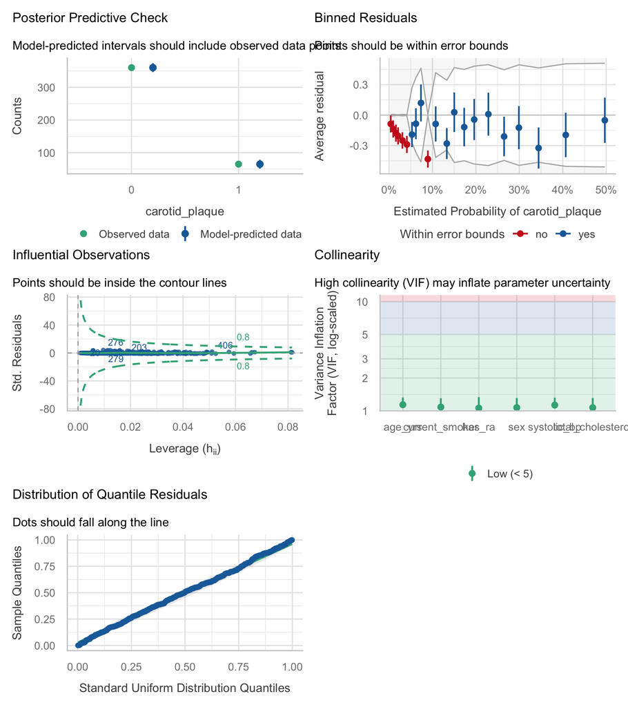

| Term | VIF | VIF_CI_low | VIF_CI_high | SE_factor | Tolerance | Tolerance_CI_low | Tolerance_CI_high |
| --- | --- | --- | --- | --- | --- | --- | --- |
| age_yrs | 1.140089 | 1.059909 | 1.327581 | 1.067750 | 0.8771245 | 0.7532500 | 0.9434774 |
| sex | 1.072992 | 1.016962 | 1.314115 | 1.035854 | 0.9319730 | 0.7609683 | 0.9833213 |
| has_ra | 1.061164 | 1.011110 | 1.336716 | 1.030128 | 0.9423612 | 0.7481020 | 0.9890117 |
| systolic_bp | 1.131084 | 1.053560 | 1.320819 | 1.063524 | 0.8841076 | 0.7571059 | 0.9491629 |
| current_smoker | 1.084596 | 1.023410 | 1.305703 | 1.041440 | 0.9220019 | 0.7658712 | 0.9771253 |
| total_cholesterol | 1.072430 | 1.016665 | 1.314793 | 1.035582 | 0.9324621 | 0.7605760 | 0.9836081 |

**Table 3. Checks for separation and undue influence.**

| Check | Value |
| --- | --- |
| Largest \|coefficient\| (log-odds scale) | 0.87 |
| Largest standard error | 0.355 |
| Largest variance inflation factor | 1.14 |
| Largest Cook's distance | 0.031 |
| Largest leverage | 0.082 |
| Smallest cell: events in the smaller level of a binary predictor | 16 |

For a logistic model, **homogeneity of variance and normality of residuals do not apply and are not interpreted** - the panels `check_model()` draws for them are ignored here. The checks that do matter are these four.

**Calibration (binned residuals).** This is the check that fails. Only about 67% of binned residuals fall inside the error bounds against a target of 95% or more, so `binned_residuals()` reports a probably-bad fit. Part of this is unavoidable noise: with 65 events spread over 425 observations each bin holds only a handful of events. Part of it is real - the pattern is consistent with the linear-in-log-odds assumption for age being imperfect, since plaque prevalence is essentially zero below age 40 and then accelerates.

**Collinearity is not a problem.** The largest variance inflation factor is 1.14, far below the conventional threshold of 5, so none of the six coefficients is competing with another for the same variance. That is a consequence of the exclusions in Methods rather than luck: adding `ldl_cholesterol` alongside total cholesterol, HDL and triglycerides drives the lipid VIFs into the hundreds.

**No separation and no influential observations.** Every coefficient is finite, the largest on the log-odds scale being 0.87, and the largest standard error is 0.35 - both entirely ordinary, and there is no “fitted probabilities numerically 0 or 1” warning. Every level of every binary predictor contains events (the sparsest combination still has 16). The largest Cook’s distance is 0.031 and the largest leverage 0.082, so no single participant drives the fit.

**Events per parameter.** 10.8, just above the conventional ten. The model is at its capacity; a seventh predictor would take it below.

# Discussion

In this Dutch case-control sample, carotid plaque is predicted by age, sex and current smoking, and not by rheumatoid arthritis. Each decade of age multiplies the odds of plaque by about 3.1, men have about 2.4 times the odds of women, and current smokers about 2.2 times the odds of non-smokers, each holding the others constant. RA status is null both crudely (OR 0.84 (95% CI 0.48 to 1.50)) and after adjustment (OR 0.70 (95% CI 0.37 to 1.35)). Practically, this says that in these patients the presence of plaque tracks the ordinary determinants of atherosclerosis, and that a clinician screening RA patients should be looking at their age, sex and smoking rather than treating the RA diagnosis itself as the risk marker.

The smoking result is the one worth dwelling on, because it only appears after adjustment. Crudely, smokers look no different from non-smokers; that is an artefact of the age distribution: smokers are 1.3 years younger on average and make up only 15% of the over-60s, the age band where most of the plaque is, while `current_smoker` counts ex-smokers as unexposed. Once age is held constant the expected doubling of odds emerges. This is a clean illustration of why an unadjusted analysis can be not merely imprecise but directionally misleading.

A word is also owed to `statins` and `antihypertensives`, which are in the dataset and were **not** used here. Both are treatment indicators, and treatment is given because of risk: statin users in this sample are on average 5.6 years older than non-users and, despite being treated, still have total cholesterol of 4.8 mmol/L against 5.5 in non-users. Put into a plaque model, they act as proxies for prior cardiovascular risk and appear harmful; adjusted for the cholesterol and blood pressure they were prescribed to lower, they are being conditioned on their own mediators. Neither reading is a treatment effect, and with a six-parameter budget spending two parameters on uninterpretable coefficients would be poor economy.

**Limitations.** The most serious problem is **differential missingness of the outcome**. 39 of 163 controls (24%) have no plaque reading against 3 of 307 RA cases (1.0%), so the exposure group of interest is nearly completely scanned while a quarter of the comparison group is not. Complete-case analysis is unbiased here only if being scanned is unrelated to plaque status among controls, which is untestable and unlikely if scanning was prompted by clinical suspicion. The design is cross-sectional, so no temporal ordering is established; the RA coefficient cannot be read as an effect of developing RA, and smoking status is current status, not lifetime exposure, with ex-smokers misclassified as unexposed - a misclassification that biases the smoking odds ratio toward the null and means the true association is probably stronger than reported. With only 65 events the model can carry six parameters, so adiposity, glucose, the full lipid panel and RA disease activity are all omitted, and residual confounding is certain. RA disease duration, DAS28, methotrexate and anti-TNF exposure are **not in this extract at all**, being undefined for controls, so a null RA coefficient cannot rule out an association confined to patients with active or long-standing disease. The binned-residual check fails, indicating imperfect calibration. Complete-case analysis dropped 45 of 470 rows. The sample is a single Dutch centre. All estimates are associations, not causal effects.

**Future work.** Establish why a quarter of controls have no plaque reading and, if the reason is administrative rather than clinical, refit with multiple imputation of the outcome-adjacent covariates; separately, model plaque with age as a spline to address the calibration failure.

# Feasibility notes

*NOT part of a student report.*